# Lecture Demo

```python
import numpy as np
import scipy.special as special
import matplotlib.pyplot as plt
from scipy.optimize import root_scalar
```

## Example 3.4.1

We will use Householder reflections to produce a QR factorization of a matrix.

```python
A = 1.0 + np.floor(9 * np.random.rand(6,4))
m, n = A.shape
print(m, n)
print(A)
```

```
6 4
[[5. 6. 2. 7.]
 [4. 4. 6. 3.]
 [2. 7. 6. 6.]
 [5. 1. 1. 2.]
 [4. 9. 7. 6.]
 [1. 7. 1. 3.]]
```

Our first step is to introduce zeros below the diagonal in column 1 by using (3.4.4) and (3.4.1).

```python
z = A[:, 0]
v = z - np.linalg.norm(z) * np.hstack([1, np.zeros(m-1)])
P_1 = np.eye(m) - (2 / np.dot(v, v)) * np.outer(v, v)
```

We check that this reflector introduces zeros as it should:

```python
print(P_1 @ z)
```

```
[9.32737905e+00 8.88178420e-16 3.33066907e-16 8.88178420e-16
 8.88178420e-16 2.22044605e-16]
```

Now we replace $A$ by $P_1A$

```python
A = P_1 @ A
print(A)
```

```
[[ 9.32737905e+00  1.15788154e+01  8.57690028e+00  1.02922803e+01]
 [ 5.96744876e-16 -1.15676146e+00 -7.93382766e-02 -4.32095678e-02]
 [ 2.98372438e-16  4.42161927e+00  2.96033086e+00  4.47839522e+00]
 [ 8.04911693e-16 -5.44595182e+00 -6.59917285e+00 -1.80401196e+00]
 [ 8.18789481e-16  3.84323854e+00  9.20661723e-01  2.95679043e+00]
 [ 2.22044605e-16  5.71080964e+00 -5.19834569e-01  2.23919761e+00]]
```

We are set to put zeros into column 2. We must not use row 1 in any way, lest it destroy the zeros we just introduced. So we leave it out of the next reflector.

```python
z = A[1:, 1]
v = z - np.linalg.norm(z) * np.hstack([1, np.zeros(m-2)])
P_2 = np.eye(m-1) - (2 / np.dot(v, v)) * np.outer(v, v)
```

We now apply this reflector to rows 2 and below only.

```python
A[1:, 1:] = P_2 @ A[1:, 1:]
print(A)
```

```
[[ 9.32737905e+00  1.15788154e+01  8.57690028e+00  1.02922803e+01]
 [ 5.96744876e-16  9.89601104e+00  5.02118025e+00  5.43932156e+00]
 [ 2.98372438e-16 -6.43699158e-16  9.19887975e-01  2.28512965e+00]
 [ 8.04911693e-16  1.87367557e-16 -4.08603163e+00  8.97355538e-01]
 [ 8.18789481e-16 -2.97966023e-17 -8.52876039e-01  1.05042034e+00]
 [ 2.22044605e-16 -2.89185068e-16 -3.15519962e+00 -5.93547897e-01]]
```

We need to iterate the process for the last two columns.

```python
for j in [2, 3]:
    z = A[j:, j]
    v = z - np.linalg.norm(z) * np.hstack([1, np.zeros(m-j-1)])
    P = np.eye(m-j) - (2 / np.dot(v, v)) * np.outer(v, v)
    A[j:, j:] = P @ A[j:, j:]
```

We have now reduced the original to an upper triangular matrix using four orthogonal Householder reflections:

```python
print(A)
```

```
[[ 9.32737905e+00  1.15788154e+01  8.57690028e+00  1.02922803e+01]
 [ 5.96744876e-16  9.89601104e+00  5.02118025e+00  5.43932156e+00]
 [ 2.98372438e-16 -6.43699158e-16  5.31267640e+00 -1.10617702e-01]
 [ 8.04911693e-16  1.87367557e-16  5.66612414e-16  2.73322341e+00]
 [ 8.18789481e-16 -2.97966023e-17  1.61213163e-16 -1.13672548e-18]
 [ 2.22044605e-16 -2.89185068e-16  4.73361669e-16 -9.27120836e-17]]
```

```python
R = np.triu(A)
print(R)
```

```
[[ 9.32737905 11.57881538  8.57690028 10.29228033]
 [ 0.          9.89601104  5.02118025  5.43932156]
 [ 0.          0.          5.3126764  -0.1106177 ]
 [ 0.          0.          0.          2.73322341]
 [ 0.          0.          0.          0.        ]
 [ 0.          0.          0.          0.        ]]
```

## The rootfinding problem

### Example 4.1.1 (The rootfinding problem for Bessel functions)

$$x^2 \frac{d^2 y}{dx^2} + x \frac{dy}{dx} + (x^2 - n^2) y = 0 \\ J_n(x) = \frac{1}{\pi} \int_0^\pi \cos(n t - x \sin t) \, dt \\ J_n(x) = \sum_{k=0}^{\infty} (-1)^k \frac{1}{k! \, \Gamma(k+n+1)} \left( \frac{x}{2} \right)^{2k+n}$$

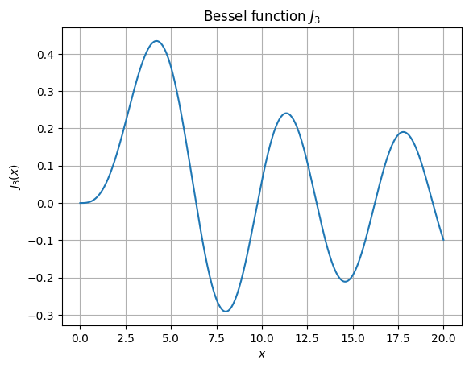

```python
def J3(x):
    return special.jv(3.0, x)

xx = np.linspace(0, 20, 500)
fig, ax = plt.subplots()
ax.plot(xx, J3(xx))
ax.grid()
plt.xlabel("$x$"), plt.ylabel("$J_3(x)$")
plt.title("Bessel function $J_3$");
```

From the graph we see roots near 6, 10, 13, 16, and 19. We use root_scalar from the scipy.optimize package to find these roots accurately.

```python
from prettytable import PrettyTable
```

```python
omega = []
for guess in [6.0, 10.0, 13.0, 16.0, 19.0]:
    s = root_scalar(J3, bracket=[guess - 0.5, guess + 0.5]).root
    omega.append(s)

results = PrettyTable()
results.add_column("root estimate", omega)
results.add_column("function value", [J3(ω) for ω in omega])
print(results)
```

```
+--------------------+-------------------------+
|   root estimate    |      function value     |
+--------------------+-------------------------+
| 6.380161895923983  |  -6.469264601473207e-17 |
| 9.761023129981195  | -1.1824718824668837e-13 |
| 13.015200721698434 |  -1.135864957485476e-16 |
| 16.223466160318758 | -2.1759276939231866e-15 |
| 19.40941522643501  |  7.862906169587308e-16  |
+--------------------+-------------------------+
```

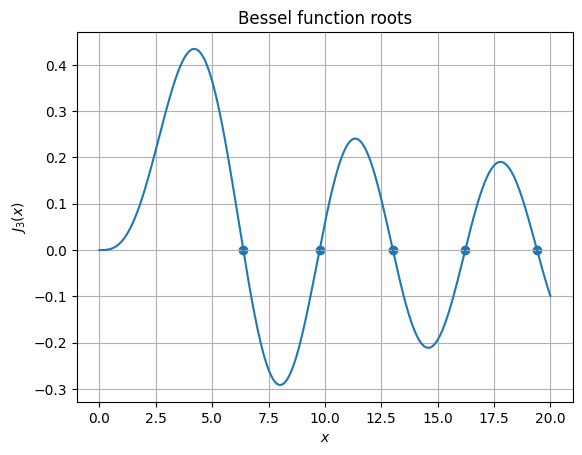

```python
ax.scatter(omega, J3(omega))
ax.set_title("Bessel function roots")
fig
```

If instead we seek values at which $J_3(x)=0.2$, then we must find roots of the function $J_3(x)−0.2$.

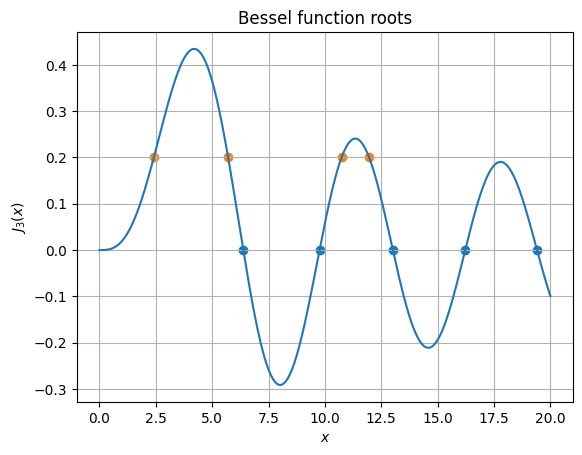

```python
omega = []
for guess in [3., 6., 10., 13.]:
    f = lambda x: J3(x) - 0.2
    s = root_scalar(f, x0=guess).root
    omega.append(s)

ax.scatter(omega, J3(omega))
fig
```

### Example 4.1.2 (Condition number of a rootfinding problem)

Consider first the function

```python
f = lambda x: (x - 1) * (x - 2)
```

At the root $r=1$, we have $f'(r)=-1$. If the values of $f$ were perturbed at every point by a small amount of noise, we can imagine finding the root of the function drawn with a thick ribbon, giving a range of potential roots.

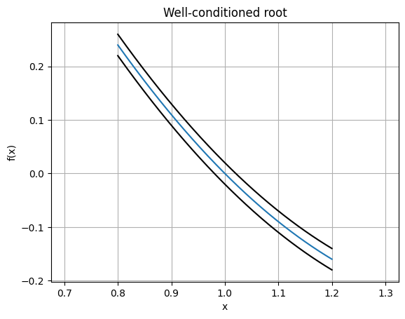

```python
xx = np.linspace(0.8, 1.2, 400)
plt.plot(xx, f(xx))
plt.plot(xx, f(xx) + 0.02, "k")
plt.plot(xx, f(xx) - 0.02, "k")
plt.axis("equal"), plt.grid(True)
plt.xlabel("x"), plt.ylabel("f(x)")
plt.title("Well-conditioned root");
```

The possible values for a perturbed root all lie within the interval where the ribbon intersects the x x-axis. The width of that zone is about the same as the vertical thickness of the ribbon.

By contrast, consider the function

```python
f = lambda x: (x - 1) * (x - 1.01)
```

Now $f'(1)=-0.01$, and the graph of $f$ will be much shallower near $x=1$. Look at the effect this has on our thick rendering:

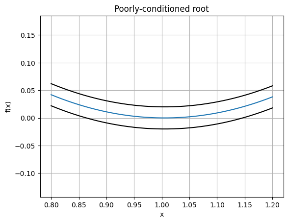

```python
xx = np.linspace(0.8, 1.2, 400)
plt.plot(xx, f(xx))
plt.plot(xx, f(xx) + 0.02, "k")
plt.plot(xx, f(xx) - 0.02, "k")
plt.axis("equal"), plt.grid(True)
plt.xlabel("x"), plt.ylabel("f(x)")
plt.title("Poorly-conditioned root");
```

The vertical displacements in this picture are exactly the same as before. But the potential horizontal displacement of the root is much wider. In fact, if we perturb the function entirely upward by the amount drawn here, the root disappears!

## Fixed point iteration

Given a function $g$, the fixed-point problem is to find a value $p$, called a fixed point, such that $g(p)=p$.

### Example 4.2.1

Let’s convert the roots of a quadratic polynomial $f(x)$ to a fixed point problem.

```python
f = np.poly1d([1, -4, 3.5])
r = f.roots
print(r)
```

```
[2.70710678 1.29289322]
```

We define $g(x)=x-f(x)$

```python
g = lambda x: x - f(x)
```

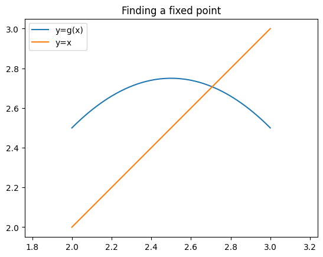

```python
fig, ax = plt.subplots()
g = lambda x: x - f(x)
xx = np.linspace(2, 3, 400)
ax.plot(xx, g(xx), label="y=g(x)")
ax.plot(xx, xx, label="y=x")
plt.axis("equal"), plt.legend()
plt.title("Finding a fixed point");
```

If we evaluate $g(2.1)$, we get a value of almost 2.6, so this is not a fixed point.

```python
x = 2.1
y = g(x)
print(y)
```

```
2.59
```

However, $y=g(x)$ is considerably closer to the fixed point at around 2.7 than $x$ is. Suppose then that we adopt $y$ as our new $x$ value. Changing the $x$ coordinate in this way is the same as following a horizontal line over to the graph of $y=x$.

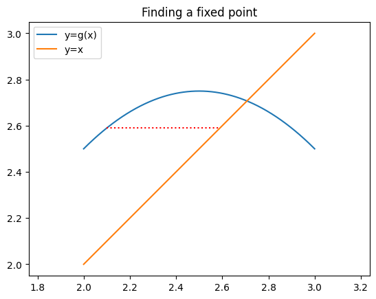

```python
ax.plot([x, y], [y, y], "r:", label="")
fig
```

Now we can compute a new value for $y$. We leave $x$ alone here, so we travel along a vertical line to the graph of $g$.

```
y: 2.7419000000000002
```

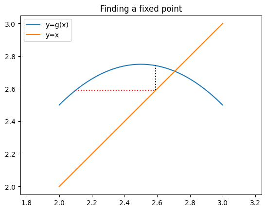

```python
x = y
y = g(x)
print("y:", y)
ax.plot([x, x], [x, y], "k:")
fig
```

You see that we are in a position to repeat these steps as often as we like. Let’s apply them a few times and see the result.

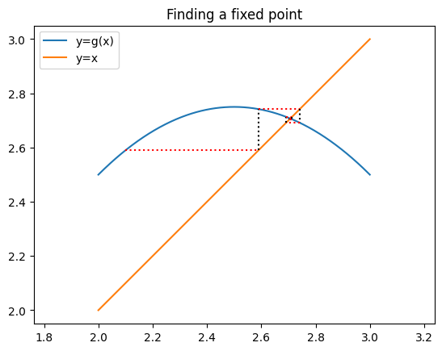

```python
for k in range(5):
    ax.plot([x, y], [y, y], "r:")
    x = y       # y --> new x
    y = g(x)    # g(x) --> new y
    ax.plot([x, x], [x, y], "k:")
fig
```

The process spirals in beautifully toward the fixed point we seek. Our last estimate has almost 4 accurate digits.

```python
print(abs(y - max(r)) / max(r))
```

```
0.0001653094344995643
```

Now let’s try to find the other fixed point ≈1.29 in the same way. We’ll use 1.3 as a starting approximation.

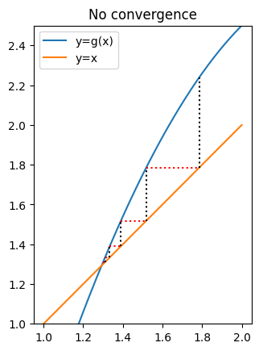

```python
xx = np.linspace(1, 2, 400)
fig, ax = plt.subplots()
ax.plot(xx, g(xx), label="y=g(x)")
ax.plot(xx, xx, label="y=x")
ax.set_aspect(1.0)
ax.legend()

x = 1.3
y = g(x)
for k in range(5):
    ax.plot([x, y], [y, y], "r:")
    x = y
    y = g(x)
    ax.plot([x, x], [x, y], "k:")
plt.ylim(1, 2.5)
plt.title("No convergence");
```

This time, the iteration is pushing us away from the correct answer.

### Example 4.2.3

We revisit Example 4.2.1 and investigate the observed convergence more closely.

```python
f = np.poly1d([1, -4, 3.5])
r = f.roots
print(r)
```

```
[2.70710678 1.29289322]
```

Here is the fixed-point iteration. This time we keep track of the whole sequence of approximations.

```python
g = lambda x: x - f(x)
x = np.zeros(12)
x[0] = 2.1
for k in range(11):
    x[k + 1] = g(x[k])

print(x)
```

```
[2.1        2.59       2.7419     2.69148439 2.71333373 2.70448872
 2.70818436 2.70665927 2.70729195 2.70703005 2.70713856 2.70709362]
```

It’s illuminating to construct and plot the sequence of errors.

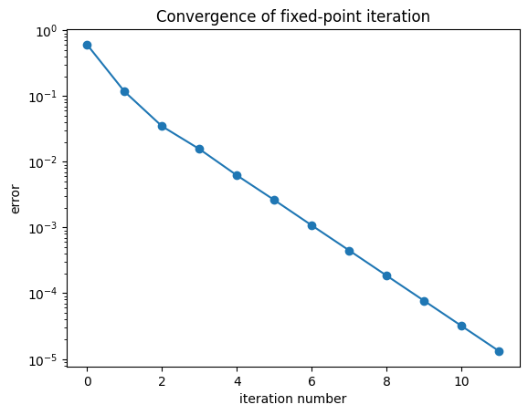

```python
err = abs(x - max(r))
plt.semilogy(err, "-o")
plt.xlabel("iteration number"), plt.ylabel("error")
plt.title("Convergence of fixed-point iteration");
```

It’s quite clear that the convergence quickly settles into a linear rate. We could estimate this rate by doing a least-squares fit to a straight line. Keep in mind that the values for small k should be left out of the computation, as they don’t represent the linear trend.

```python
p = np.polyfit(np.arange(5, 13), np.log(err[4:]), 1)
print(p)
```

```
[-0.88071816 -0.66805739]
```

We can exponentiate the slope to get the convergence constant σ.

```python
print("sigma:", np.exp(p[0]))
```

```
sigma: 0.4144851385485472
```

The error should therefore decrease by a factor of σ at each iteration. We can check this easily from the observed data.

```python
err[8:] / err[7:-1]
```

```
array([0.41376605, 0.41439873, 0.41413683, 0.41424534])
```

The methods for finding σ agree well.

# [P] Chapter 9 Data Analysis with pandas

## Introduction

```python
import pandas as pd
```

https://pandas.pydata.org/

```python
river_lengths = pd.Series([6300, 6650, 6275, 6400])
river_lengths
```

|  | 0 |
| --- | --- |
| 0 | 6300 |
| 1 | 6650 |
| 2 | 6275 |
| 3 | 6400 |

**dtype:** int64

```python
river_lengths = pd.Series([6300, 6650, 6275, 6400], name='Length /km',
dtype=float)
river_lengths
```

|  | Length /km |
| --- | --- |
| 0 | 6300.0 |
| 1 | 6650.0 |
| 2 | 6275.0 |
| 3 | 6400.0 |

**dtype:** float64

```python
river_lengths[1]
```

```
np.float64(6650.0)
```

```python
river_lengths.iloc[1]
```

```
np.float64(6650.0)
```

```python
river_lengths = pd.Series(data={'Yangtze': 6300, 'Nile': 6650,'Mississippi': 6275, 'Amazon': 6400},name='Length /km')
river_lengths
```

|  | Length /km |
| --- | --- |
| Yangtze | 6300 |
| Nile | 6650 |
| Mississippi | 6275 |
| Amazon | 6400 |

**dtype:** int64

```python
river_lengths['Nile']
```

```
np.int64(6650)
```

```python
river_lengths['Nile':'Amazon']
```

|  | Length /km |
| --- | --- |
| Nile | 6650 |
| Mississippi | 6275 |
| Amazon | 6400 |

**dtype:** int64

```python
river_lengths.Mississippi
```

```
np.int64(6275)
```

```python
river_lengths > 4000
```

|  | Length /km |
| --- | --- |
| Yangtze | True |
| Nile | True |
| Mississippi | True |
| Amazon | True |

**dtype:** bool

```python
'Yangtze' in river_lengths
```

```
True
```

```python
river_lengths.sort_index()
```

|  | Length /km |
| --- | --- |
| Amazon | 6400 |
| Mississippi | 6275 |
| Nile | 6650 |
| Yangtze | 6300 |

**dtype:** int64

```python
river_lengths.sort_values(ascending=False , inplace=True)
river_lengths
```

|  | Length /km |
| --- | --- |
| Nile | 6650 |
| Amazon | 6400 |
| Yangtze | 6300 |
| Mississippi | 6275 |

**dtype:** int64

```python
masses = pd.Series({'Ganymede': 1.482e23,
  'Callisto': 1.076e23,
  'Io': 8.932e22,
  'Europa': 4.800e22,
  'Moon': 7.342e22,
  'Earth': 5.972e24}, name='mass /kg')
radii = pd.Series({'Ganymede': 2.634e6,
  'Io': 1.822e6,
  'Moon': 1.737e6,
  'Earth': 6.371e6}, name='radius /m')
from scipy.constants import G
surface_g = G * masses / radii**2
surface_g.name = 'surface gravity /m.s-2'
surface_g.index.name = 'Body'
surface_g
```

| Body | surface gravity /m.s-2 |
| --- | --- |
| Callisto | NaN |
| Earth | 9.819973 |
| Europa | NaN |
| Ganymede | 1.425681 |
| Io | 1.795799 |
| Moon | 1.624129 |

**dtype:** float64

```python
surface_g.dropna()
```

| Body | surface gravity /m.s-2 |
| --- | --- |
| Earth | 9.819973 |
| Ganymede | 1.425681 |
| Io | 1.795799 |
| Moon | 1.624129 |

**dtype:** float64

## Reading and Writing Series and DataFrames

```python
# https://scipython.com/eg/baq/
df = pd.read_csv('https://scipython.com/documents/44/ionization-energies.csv', skiprows=1, index_col=0,usecols=range(5), nrows=11)
```

```python
df
```

| Element | IE1 | IE2 | IE3 | IE4 |
| --- | --- | --- | --- | --- |
| H | 13.59844 | NaN | NaN | NaN |
| He | 24.58741 | 54.41778 | NaN | NaN |
| Li | 5.39172 | 75.64018 | 122.45429 | NaN |
| Be | 9.32270 | 18.21116 | 153.89661 | 217.71865 |
| B | 8.29803 | 25.15484 | 37.93064 | 259.37521 |
| C | 11.26030 | 24.38332 | 47.88780 | 64.49390 |
| N | 14.53414 | 29.60130 | 47.44924 | 77.47350 |
| O | 13.61806 | 35.11730 | 54.93550 | 77.41353 |
| F | 17.42282 | 34.97082 | 62.70840 | 87.13980 |
| Ne | 21.56460 | 40.96328 | 63.45000 | 97.12000 |
| Na | 5.13908 | 47.28640 | 71.62000 | 98.91000 |

```python
df.columns = df.columns.str.strip()
print('Second ionization energy of Li: {} eV'.format(df.loc['Li'].IE2))
```

```
Second ionization energy of Li: 75.64018 eV
```

```python
def average_rda_in_micrograms(col):
  def ensure_micrograms(s):
    if s.endswith('ug'):
      return float(s[:-2])
    elif s.endswith('mg'):
      return float(s[:-2]) * 1000
    raise ValueError(f'Unrecognised units in {s}')
  fields = col.split('/')
  return sum([ensure_micrograms(s) for s in fields]) / len(fields)
# https://scipython.com/eg/bao/
df = pd.read_csv('https://scipython.com/documents/45/vitamins.txt', sep=r'\s+', skiprows=4,
  skipfooter=1, header=None, usecols=(1, 2, 3),
  converters={'RDA': average_rda_in_micrograms},
  names=['Vitamin', 'Solubility', 'RDA'],
  index_col=0,  engine='python'
  )
df
```

| Vitamin | Solubility | RDA |
| --- | --- | --- |
| A | Fat | 800.0 |
| B1 | Water | 1150.0 |
| B2 | Water | 1200.0 |
| B3 | Water | 15000.0 |
| B5 | Water | 5000.0 |
| B6 | Water | 1450.0 |
| B7 | Water | 30.0 |
| B9 | Water | 400.0 |
| B12 | Water | 2.4 |
| C | Water | 82500.0 |
| D | Fat | 15.0 |
| E | Fat | 15000.0 |
| K | Fat | 115.0 |

## Other examples

```python
df = pd.read_csv("/content/sample_data/california_housing_train.csv")
```

```python
df.head()
```

|  | longitude | latitude | housing_median_age | total_rooms | total_bedrooms | population | households | median_income | median_house_value |
| --- | --- | --- | --- | --- | --- | --- | --- | --- | --- |
| 0 | -114.31 | 34.19 | 15.0 | 5612.0 | 1283.0 | 1015.0 | 472.0 | 1.4936 | 66900.0 |
| 1 | -114.47 | 34.40 | 19.0 | 7650.0 | 1901.0 | 1129.0 | 463.0 | 1.8200 | 80100.0 |
| 2 | -114.56 | 33.69 | 17.0 | 720.0 | 174.0 | 333.0 | 117.0 | 1.6509 | 85700.0 |
| 3 | -114.57 | 33.64 | 14.0 | 1501.0 | 337.0 | 515.0 | 226.0 | 3.1917 | 73400.0 |
| 4 | -114.57 | 33.57 | 20.0 | 1454.0 | 326.0 | 624.0 | 262.0 | 1.9250 | 65500.0 |

```python
df.info()
```

```
<class 'pandas.core.frame.DataFrame'>
RangeIndex: 17000 entries, 0 to 16999
Data columns (total 9 columns):
 #   Column              Non-Null Count  Dtype
---  ------              --------------  -----
 0   longitude           17000 non-null  float64
 1   latitude            17000 non-null  float64
 2   housing_median_age  17000 non-null  float64
 3   total_rooms         17000 non-null  float64
 4   total_bedrooms      17000 non-null  float64
 5   population          17000 non-null  float64
 6   households          17000 non-null  float64
 7   median_income       17000 non-null  float64
 8   median_house_value  17000 non-null  float64
dtypes: float64(9)
memory usage: 1.2 MB
```

```python
df.describe()
```

|  | longitude | latitude | housing_median_age | total_rooms | total_bedrooms | population | households | median_income | median_house_value |
| --- | --- | --- | --- | --- | --- | --- | --- | --- | --- |
| count | 17000.000000 | 17000.000000 | 17000.000000 | 17000.000000 | 17000.000000 | 17000.000000 | 17000.000000 | 17000.000000 | 17000.000000 |
| mean | -119.562108 | 35.625225 | 28.589353 | 2643.664412 | 539.410824 | 1429.573941 | 501.221941 | 3.883578 | 207300.912353 |
| std | 2.005166 | 2.137340 | 12.586937 | 2179.947071 | 421.499452 | 1147.852959 | 384.520841 | 1.908157 | 115983.764387 |
| min | -124.350000 | 32.540000 | 1.000000 | 2.000000 | 1.000000 | 3.000000 | 1.000000 | 0.499900 | 14999.000000 |
| 25% | -121.790000 | 33.930000 | 18.000000 | 1462.000000 | 297.000000 | 790.000000 | 282.000000 | 2.566375 | 119400.000000 |
| 50% | -118.490000 | 34.250000 | 29.000000 | 2127.000000 | 434.000000 | 1167.000000 | 409.000000 | 3.544600 | 180400.000000 |
| 75% | -118.000000 | 37.720000 | 37.000000 | 3151.250000 | 648.250000 | 1721.000000 | 605.250000 | 4.767000 | 265000.000000 |
| max | -114.310000 | 41.950000 | 52.000000 | 37937.000000 | 6445.000000 | 35682.000000 | 6082.000000 | 15.000100 | 500001.000000 |

```python
df.isnull().sum()
```

|  | 0 |
| --- | --- |
| longitude | 0 |
| latitude | 0 |
| housing_median_age | 0 |
| total_rooms | 0 |
| total_bedrooms | 0 |
| population | 0 |
| households | 0 |
| median_income | 0 |
| median_house_value | 0 |

**dtype:** int64

```python
df.rename(columns={
    'housingMedianAge': 'median_age',
    'totalRooms': 'total_rooms',
    'totalBedrooms': 'total_bedrooms',
    'medianIncome': 'median_income',
    'medianHouseValue': 'median_house_value'
}, inplace=True)
```

```python
df[['median_income', 'median_house_value']].head()
```

|  | median_income | median_house_value |
| --- | --- | --- |
| 0 | 1.4936 | 66900.0 |
| 1 | 1.8200 | 80100.0 |
| 2 | 1.6509 | 85700.0 |
| 3 | 3.1917 | 73400.0 |
| 4 | 1.9250 | 65500.0 |

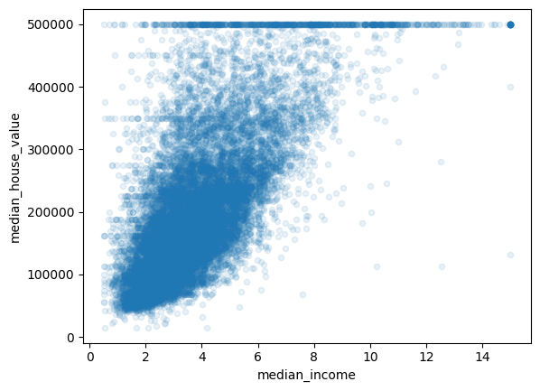

```python
df.plot(kind='scatter', x='median_income', y='median_house_value', alpha=0.1)
```

```python
df[df['median_income'] > 10]
```

|  | longitude | latitude | housing_median_age | total_rooms | total_bedrooms | population | households | median_income | median_house_value |
| --- | --- | --- | --- | --- | --- | --- | --- | --- | --- |
| 172 | -116.26 | 33.65 | 3.0 | 7437.0 | 1222.0 | 574.0 | 302.0 | 10.2948 | 382400.0 |
| 698 | -117.05 | 33.01 | 17.0 | 3430.0 | 425.0 | 1468.0 | 433.0 | 10.6186 | 429300.0 |
| 818 | -117.07 | 32.91 | 5.0 | 2234.0 | 256.0 | 894.0 | 253.0 | 10.3354 | 477600.0 |
| 1443 | -117.19 | 34.03 | 20.0 | 856.0 | 124.0 | 395.0 | 145.0 | 10.8634 | 381800.0 |
| 1528 | -117.21 | 33.03 | 20.0 | 3370.0 | 433.0 | 1020.0 | 408.0 | 11.0911 | 500001.0 |
| ... | ... | ... | ... | ... | ... | ... | ... | ... | ... |
| 16262 | -122.49 | 37.79 | 52.0 | 2488.0 | 281.0 | 805.0 | 295.0 | 10.7058 | 500001.0 |
| 16309 | -122.50 | 37.79 | 52.0 | 8.0 | 1.0 | 13.0 | 1.0 | 15.0001 | 500001.0 |
| 16357 | -122.52 | 37.92 | 24.0 | 421.0 | 64.0 | 163.0 | 75.0 | 14.5833 | 500001.0 |
| 16386 | -122.54 | 37.96 | 44.0 | 1552.0 | 204.0 | 596.0 | 208.0 | 10.1290 | 500001.0 |
| 16419 | -122.56 | 37.94 | 36.0 | 2023.0 | 242.0 | 653.0 | 241.0 | 10.6272 | 500001.0 |

259 rows × 9 columns

```python
df['rooms_per_household'] = df['total_rooms'] / df['households']
df[['total_rooms', 'households', 'rooms_per_household']].head()
```

|  | total_rooms | households | rooms_per_household |
| --- | --- | --- | --- |
| 0 | 5612.0 | 472.0 | 11.889831 |
| 1 | 7650.0 | 463.0 | 16.522678 |
| 2 | 720.0 | 117.0 | 6.153846 |
| 3 | 1501.0 | 226.0 | 6.641593 |
| 4 | 1454.0 | 262.0 | 5.549618 |

## Exercise

P 9.3.1

P 9.3.2

P 9.4.1

P 9.5.1

Use the following datasets to practice using Pandas:

https://www.kaggle.com/datasets/yasserh/titanic-dataset

https://www.kaggle.com/datasets/uciml/iris

# [R1] Chapter 8 Statistics

## 8.1 Basic concepts in statistics

```python
from scipy.stats import uniform, norm, binom
```

```python
X = uniform.rvs(size=5)
print(X)
```

```
[0.70476271 0.3264777  0.69575654 0.98371987 0.41941204]
```

```python
Y = norm.rvs(size=4)
print(Y)
```

```
[-0.49931612 -1.66229008  1.22615517 -0.95226527]
```

```python
K = binom.rvs(9, 0.5, size=3)
print(K)
```

```
[3 5 4]
```

```python
K = binom.rvs(9, 0.5, size=3, random_state=74)
print(K)
```

```
[3 6 6]
```

```python
import numpy as np
from scipy import stats
A = [3, 1, 4, 1, 5, 9]
print([np.mean(A),
  np.median(A),
  stats.mode(A, keepdims=False),
  np.var(A, ddof =1),
  np.var(A)])
```

```
[np.float64(3.8333333333333335), np.float64(3.5), ModeResult(mode=np.int64(1), count=np.int64(2)), np.float64(8.966666666666665), np.float64(7.472222222222221)]
```

## Basics of statistical packages

1 https://pandas.pydata.org

2 https://seaborn.pydata.org

3 https://scikit-learn.org

## Central Limit Theorem

**Central Limit Theorem**

Let $X_1, X_2, \ldots, X_n$ be i.i.d. random variables sampled from a distribution with mean $\mu$ and variance $ \sigma^2 $, where $ 0 < \sigma^2 < \infty $. Then, for each fixed $ x $, the sample mean $ \bar{X} $ satisfies

$$ \lim_{n \to \infty} \Pr\left( \frac{\bar{X} - \mu}{\sigma / \sqrt{n}} \leq x \right) = \Phi(x), $$

where $ \Phi $ is the cumulative distribution function (CDF) of the standard normal distribution.

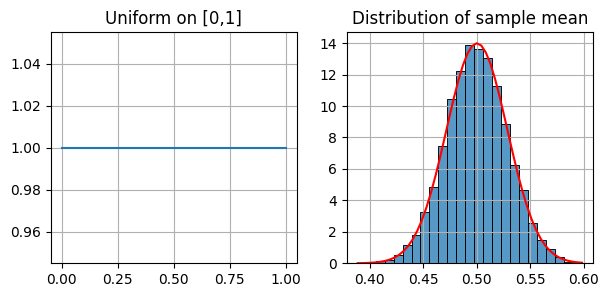

```
402 samples were >0.55. P(X>0.55)=0.0402
```

```python
import numpy as np
import matplotlib.pyplot as plt
from scipy.stats import uniform, norm
import seaborn as sns
Means = []
Musize = int(1e4)
size = 100
for i in range(Musize):
  samples = uniform.rvs(size=size)
  mu = np.mean(samples)
  Means.append(mu)
fig,(ax1, ax2)=plt.subplots(1,2,figsize=(7,3))
x1 = np.linspace(0,1)
pdf = uniform.pdf(x1)
ax1.plot(x1, pdf)
ax1.set_title(f'Uniform on [0,1]')
ax1.grid('on')
sns.histplot(Means, bins=25,
  stat = 'density', ax=ax2)
ax2.set_title(f'Distribution of sample mean')
x2 = np.linspace(min(Means), max(Means))
ax2.set_ylabel('')
MU = np.mean(Means)
SIG = np.sqrt(np.var(Means, ddof=1))
y2 = norm.pdf(x2, MU, SIG)
ax2.plot(x2,y2, 'r')
ax2.grid('on')
plt.show()
Mcount = sum(i > 0.55 for i in Means)
Ans = Mcount/Musize
print(f'{Mcount} samples were >0.55. '
  f'P(X>0.55)={Ans}')
```

## $χ^2$ distribution and goodness of fit

```
chi2 stat. = 12.8400
SciPy: chi2 stat.=12.8400

p-value = 0.0121
SciPy:p-value = 0.0121
```

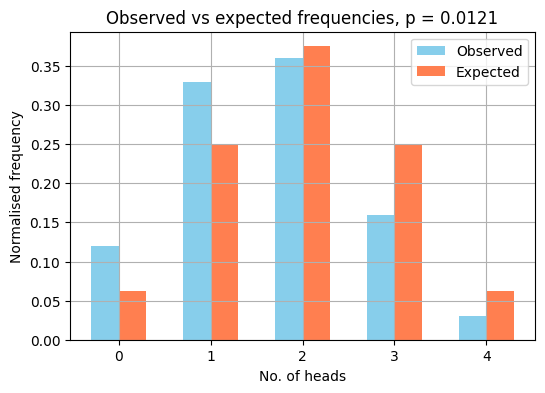

```python
import numpy as np
import matplotlib.pyplot as plt
from scipy import stats

f_obs = np.array([12, 33, 36, 16, 3])

C = len(f_obs)
Nsmpl = sum(f_obs)

X = np.arange(C)
f_exp = Nsmpl*stats.binom.pmf(X, C-1, 0.5)

chisq = sum((f_obs - f_exp)**2/f_exp)

res = stats.chisquare(f_obs, f_exp)

print(f'chi2 stat. = {chisq:.4f}')
print(f'SciPy: chi2 stat.={res.statistic:.4f}')
print('')

rv = stats.chi2(df = C-1)
p = 1 - rv.cdf(chisq)

print(f'p-value = {p:.4f}')
print(f'SciPy:p-value = {res.pvalue:.4f}')

fig, ax = plt.subplots(1,1, figsize=(6,4))

width = 0.3
ax.bar(X - width/2, f_obs/Nsmpl,
  width = width, color = 'skyblue')
ax.bar(X + width/2, f_exp/Nsmpl,
  width = width, color = 'coral')
ax.set_title('Observed vs expected '
  f'frequencies, p = {p:.4f}')
ax.set_xlabel('No. of heads')
ax.set_ylabel('Normalised frequency')

plt.legend(['Observed', 'Expected'])
plt.grid('on')
plt.show()
```

## Linear regression and Simpson’s paradox

```python
!wget https://raw.githubusercontent.com/siriwarwick/book/main/Chapter8/datasetA.csv
!wget https://raw.githubusercontent.com/siriwarwick/book/main/Chapter8/datasetB.csv
```

[output not shown]

```python
import numpy as np
from scipy import linalg as LA
import pandas as pd
df_A = pd.read_csv('/content/datasetA.csv', sep=',',
  header=None)
x = df_A.values[:,0]
y = df_A.values[:,1]

ones = np.ones_like(x)
A = np.column_stack((x , ones))
alpha_A, beta_A = LA.solve(A.T@A, A.T@y)

print(f'alpha_A={alpha_A:.5f}, beta_A={beta_A:.5f}')

df_B = pd.read_csv('/content/datasetB.csv', sep=',',
  header=None)
x = df_B.values[:,0]
y = df_B.values[:,1]

ones = np.ones_like(x)
A = np.column_stack((x , ones))
alpha_B, beta_B = LA.solve(A.T@A, A.T@y)

print(f'alpha_B={alpha_B:.5f}, beta_B={beta_B:.5f}')

x = np.concatenate([df_A.values[:,0], df_B.values[:,0]])
y = np.concatenate([df_A.values[:,1], df_B.values[:,1]])

ones = np.ones_like(x)
A = np.column_stack((x , ones))
alpha_conbined, beta_conbined = LA.solve(A.T@A, A.T@y)

print(f'alpha_conbined={alpha_conbined:.5f}, beta_conbined={beta_conbined:.5f}')
```

```
alpha_A=0.64874, beta_A=-4.90148
alpha_B=0.59491, beta_B=3.88723
alpha_conbined=-0.28755, beta_conbined=0.84805
```

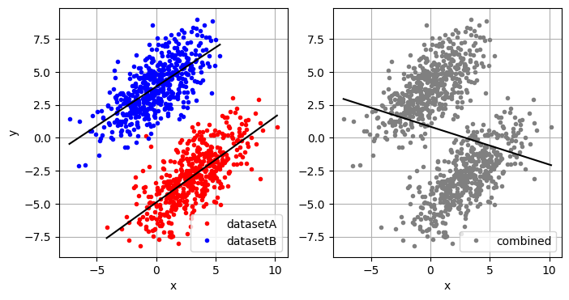

```python
import numpy as np
import matplotlib.pyplot as plt
from numpy.polynomial import Polynomial as P
import pandas as pd

fig,(ax1,ax2) = plt.subplots(1,2,figsize=(8,4))

df1 = pd.read_csv('/content/datasetA.csv', sep=',',
  header=None)
x1 = df1.values[:,0]
y1 = df1.values[:,1]
ax1.plot(x1,y1,'.r')

df2 = pd.read_csv('/content/datasetB.csv', sep=',',
header=None)
x2 = df2.values[:,0]
y2 = df2.values[:,1]
ax1.plot(x2,y2,'.b')

ax1.legend(['datasetA','datasetB'],
  loc='lower right')

poly1 = P.fit(x1, y1, 1).convert()
xfit1 = np.linspace(min(x1),max(x1))
yfit1 = poly1(xfit1)
ax1.plot(xfit1, yfit1, 'k')

poly2 = P.fit(x2, y2, 1).convert()
xfit2 = np.linspace(min(x2),max(x2))
yfit2 = poly2(xfit2)
ax1.plot(xfit2, yfit2, 'k')

ax1.set_xlabel('x')
ax1.set_ylabel('y')
ax1.grid('on')

X = np.concatenate((x1,x2))
Y = np.concatenate((y1,y2))
ax2.plot(X,Y,'.', c='gray')
ax2.legend(['combined'], loc='lower right')

Poly = P.fit(X, Y, 1).convert()
Xfit = np.linspace(min(X),max(X))
Yfit = Poly(Xfit)
ax2.plot(Xfit, Yfit, 'k')

ax2.set_xlabel('x')
ax2.grid('on')

plt.show()
```

## Bivariate normal distribution

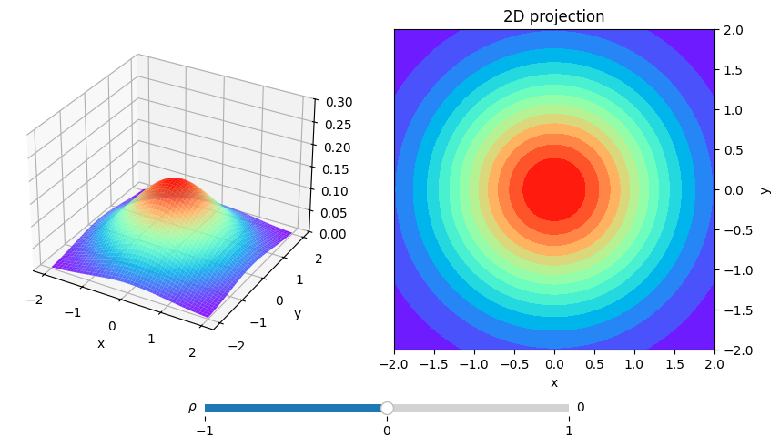

```python
import numpy as np
import matplotlib.pyplot as plt
from matplotlib.widgets import Slider
from scipy.stats import multivariate_normal

rho = 0.5
S1, S2 = 1, 1

S12 = np.sqrt(S1*S2)

fig = plt.figure(figsize=(10,6))
plt.subplots_adjust(bottom=0.15)

ax1 = fig.add_subplot(121, projection='3d')
ax2 = fig.add_subplot(122)
ax2.set_box_aspect(1)
ax2.set_title('2D projection')
ax2.yaxis.tick_right();
ax2.yaxis.set_label_position('right')
ax2.set_xlabel('x'); ax2.set_ylabel('y')

xplot = np.linspace(-2,2)
yplot = np.linspace(-2,2)
X, Y = np.meshgrid(xplot,yplot)

def plots(rho):
  Cov = [(S1, rho*S12), (rho*S12, S2)]
  rv = multivariate_normal(cov = Cov)
  Z = rv.pdf(np.dstack([X,Y]))
  cmap = 'rainbow'
  plot1 = ax1.plot_surface(X, Y, Z,
    alpha=0.9, cmap=cmap)
  ax1.set_zlim(0, 0.3)
  ax1.set_xlabel('x')
  ax1.set_ylabel('y')
  levels = np.linspace(0,np.max(Z),15)
  plot2 = ax2.contourf(X, Y, Z,
    levels = levels, cmap=cmap)
  return plot1, plot2
axt = plt.axes([0.34, 0.1, 0.4, 0.03])
rho_slide = Slider(axt, r'$\rho$',
  -1, 1, valstep=0.01, valinit=0)
axt.add_artist(axt.xaxis)
axt.set_xticks([-1,0,1])

plots(0)

def update(val):
  ax1.clear()
  rho = rho_slide.val
  plots(rho)

rho_slide.on_changed(update)
plt.show()
```

## Random walks

A particle is initially at $x_0 = 0$. In each time step, it moves left or right by a distance 1 unit with equal probability. Find the expected value of the distance from the origin after N steps.

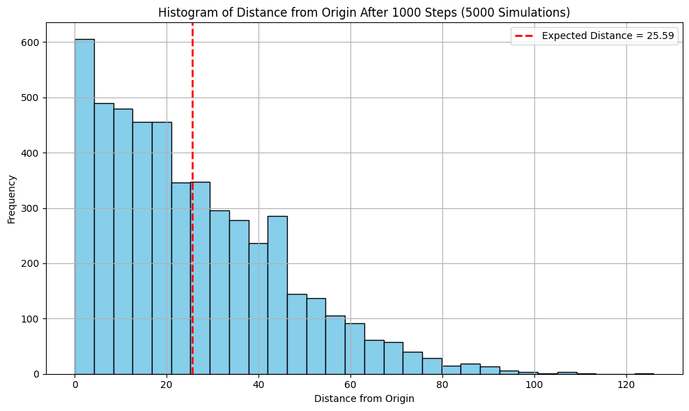

```python
import numpy as np
import matplotlib.pyplot as plt

# Set random seed for reproducibility
np.random.seed(0)

# Parameters
N = 1000  # number of steps
num_simulations = 5000  # number of random walk simulations

# Perform multiple random walks
final_positions = []
distances_from_origin = []

for _ in range(num_simulations):
    steps = np.random.choice([-1, 1], size=N)
    position = np.cumsum(steps)  # position after each step
    final_positions.append(position[-1])
    distances_from_origin.append(abs(position[-1]))

# Calculate expected distance from origin
expected_distance = np.mean(distances_from_origin)

# Plot histogram of distances from origin
plt.figure(figsize=(10, 6))
plt.hist(distances_from_origin, bins=30, color='skyblue', edgecolor='black')
plt.axvline(expected_distance, color='red', linestyle='dashed', linewidth=2,
            label=f'Expected Distance = {expected_distance:.2f}')
plt.title(f'Histogram of Distance from Origin After {N} Steps ({num_simulations} Simulations)')
plt.xlabel('Distance from Origin')
plt.ylabel('Frequency')
plt.legend()
plt.grid(True)
plt.tight_layout()
plt.show()
```

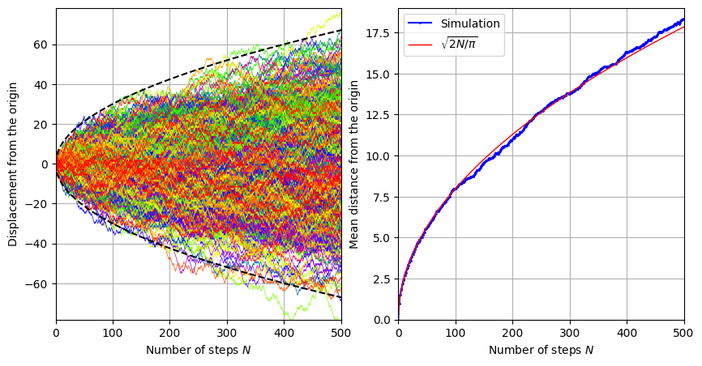

```python
import numpy as np
import matplotlib.pyplot as plt
import random

Nsims = int(1e3)
Nsteps = 500

Sims = np.arange(Nsims)
Steps= np.arange(Nsteps+1)
SumDist = np.zeros_like(Steps)

fig,(ax1, ax2)=plt.subplots(1,2,figsize=(10,5))
ax1.set_xlim(0, Nsteps)
ax1.set_ylim(-3.5*np.sqrt(Nsteps),
  3.5*np.sqrt(Nsteps))
ax1.set_xlabel('Number of steps $N$')
ax1.set_ylabel('Displacement from the origin')
ax1.grid('on')
color=plt.cm.prism_r(np.linspace(0, 1, Nsims))

for i in Sims:
  R = [random.randint(0,1) for
    i in range(1,Nsteps+1)]
  moves = 2*np.array(R)-1
  traj = np.cumsum(moves)
  traj = np.insert(traj, 0, 0)
  ax1.plot(Steps, traj, '-',
    lw = 0.5, c = color[i])
  SumDist += np.abs(traj)

bound = 3*np.sqrt(Steps)

ax1.plot(Steps, bound, 'k--',
  Steps, -bound, 'k--')

AveDist = SumDist/Nsims

ax2.plot(Steps, AveDist, 'bo-', ms=1)
ax2.plot(Steps,np.sqrt(2*Steps/np.pi),'r',lw=1)
ax2.set_xlim(0, Nsteps)
ax2.set_ylim(0, np.ceil(np.max(AveDist)))
ax2.set_xlabel(r'Number of steps $N$')
ax2.set_ylabel('Mean distance from the origin')
ax2.legend(['Simulation', r'$\sqrt{2N/\pi}$'])
ax2.grid('on')

plt.show()
```

## Machine learning: clustering and classification

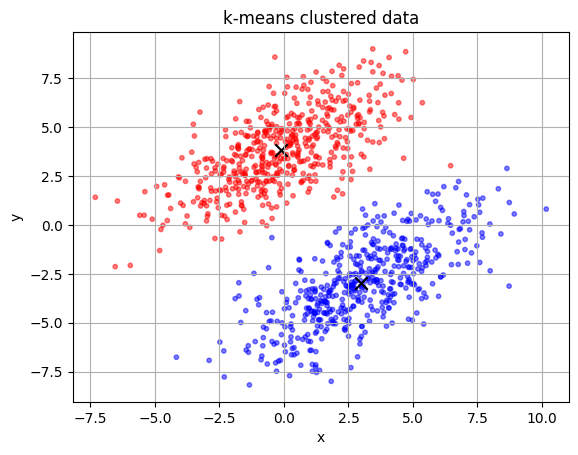

```
After 4 iterations, the centroids are at
[-0.09937072  3.81232351] and
[ 3.00014779 -2.97393273]
```

```python
import pandas as pd
import matplotlib.pyplot as plt
from sklearn.cluster import KMeans

data0 = pd.read_csv('/content/datasetA.csv',
  sep=',', header=None)
data1 = pd.read_csv('/content/datasetB.csv',
  sep=',', header=None)
X = pd.concat([data0, data1])

kmeans = KMeans(n_clusters=2, random_state=4,
  n_init='auto').fit(X)

centr = kmeans.cluster_centers_

fig, ax = plt.subplots(1,1)

ax.scatter(X.values[:,0], X.values[:,1],
  c=kmeans.labels_, cmap='bwr_r',
  s=10, alpha=0.5)
ax.scatter(centr[:,0], centr[:,1], c='k',
  s=80, marker = 'x')
ax.set_title('k-means clustered data')
ax.set_xlabel('x')
ax.set_ylabel('y')
plt.grid('on')
plt.show()

print(f'After {kmeans.n_iter_} iterations, '
'the centroids are at')
print(f'{centr[0,:]} and \n{centr[1,:]}')
```

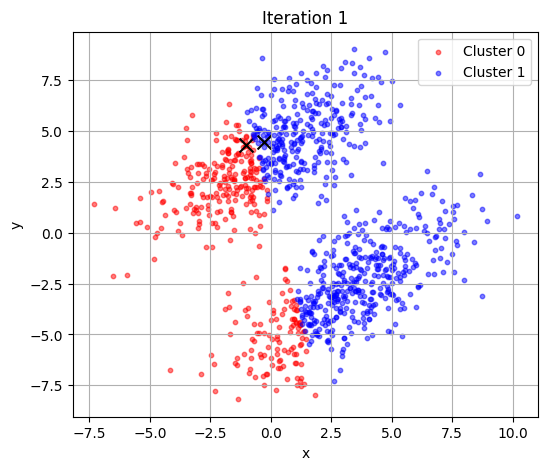

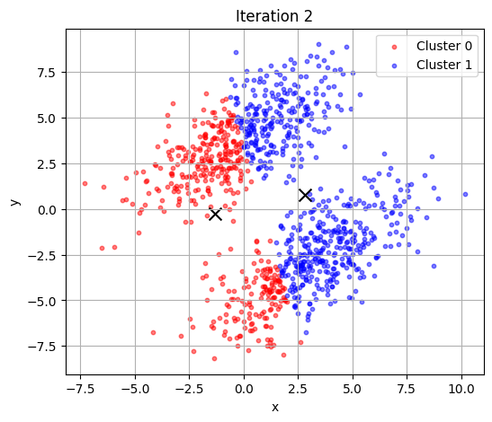

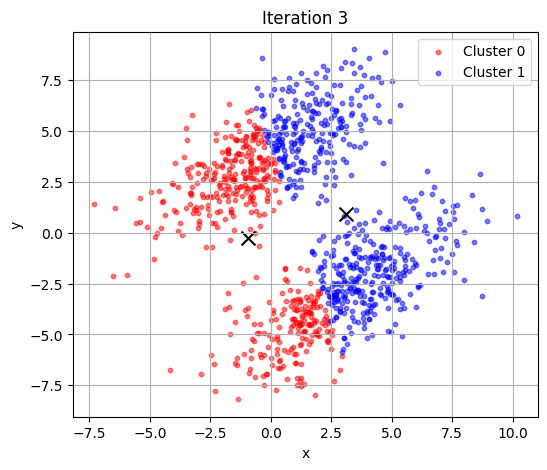

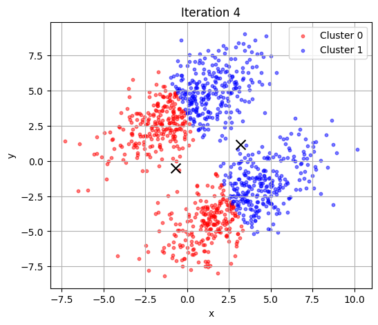

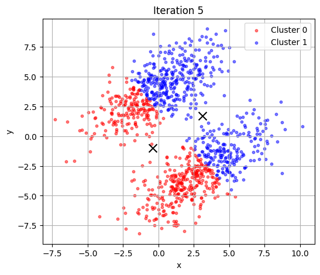

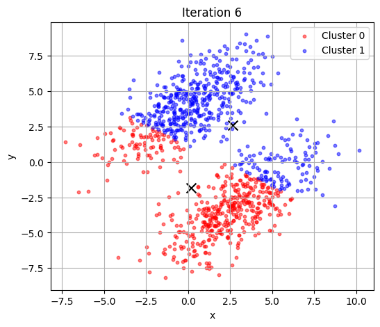

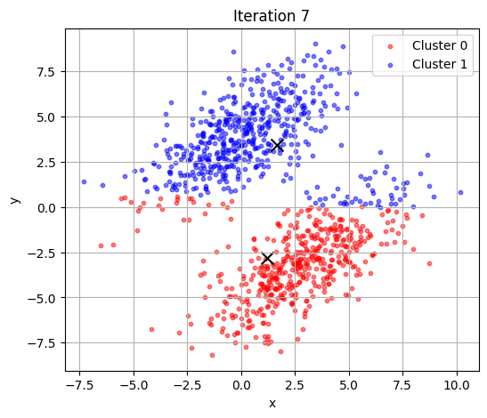

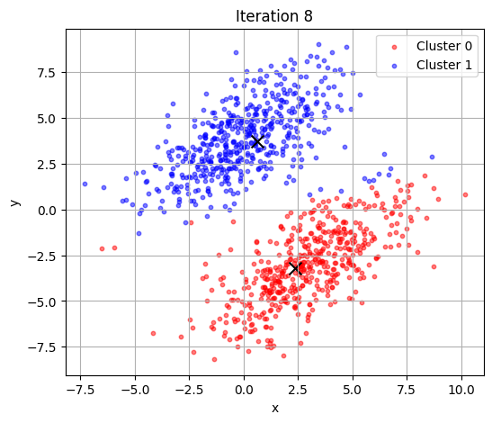

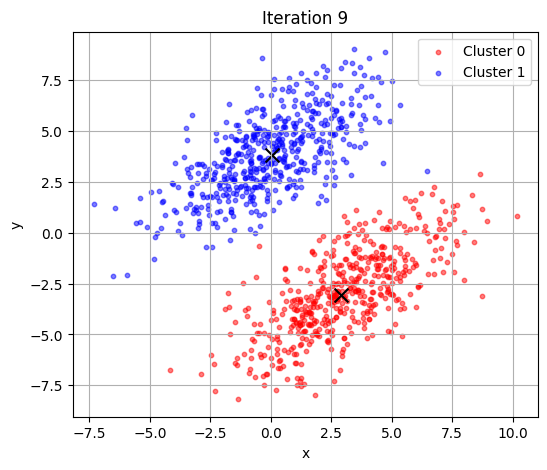

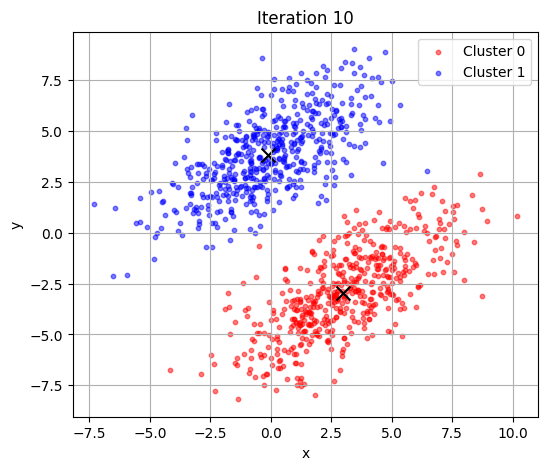

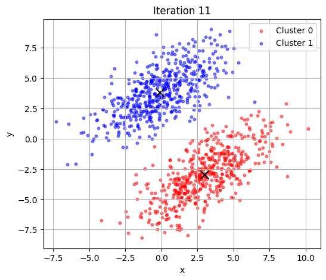

```
After 11 iterations, the centroids are:
Centroid 0: [ 3.00014779 -2.97393273]
Centroid 1: [-0.09937072  3.81232351]
```

```python
import pandas as pd
import numpy as np
import matplotlib.pyplot as plt

# Load data
data0 = pd.read_csv('/content/datasetA.csv', sep=',', header=None)
data1 = pd.read_csv('/content/datasetB.csv', sep=',', header=None)
X = pd.concat([data0, data1]).values  # Convert to NumPy array

# Parameters
k = 2
max_iter = 10  # Limit iterations for visualization
np.random.seed(4)

# Step 1: Random initialization
initial_centroids = X[np.random.choice(X.shape[0], k, replace=False)]
centroids = initial_centroids.copy()

# Function to compute Euclidean distance
def euclidean(a, b):
    return np.linalg.norm(a - b, axis=1)

# For visualization
colors = ['red', 'blue']
history = []

for i in range(max_iter):
    # Step 2: Assign points to the nearest centroid
    labels = np.array([np.argmin([np.linalg.norm(x - c) for c in centroids]) for x in X])

    # Save step for plotting
    history.append((centroids.copy(), labels.copy()))

    # Step 3: Update centroids
    new_centroids = np.array([X[labels == j].mean(axis=0) for j in range(k)])

    # Check for convergence
    if np.allclose(new_centroids, centroids):
        break

    centroids = new_centroids

# Final step for plotting
history.append((centroids.copy(), labels.copy()))

# Plot each iteration
for i, (cent, lbls) in enumerate(history):
    plt.figure(figsize=(6, 5))
    for j in range(k):
        cluster_points = X[lbls == j]
        plt.scatter(cluster_points[:, 0], cluster_points[:, 1], s=10, c=colors[j], label=f'Cluster {j}', alpha=0.5)
        plt.scatter(cent[j, 0], cent[j, 1], c='k', marker='x', s=100)
    plt.title(f'Iteration {i+1}')
    plt.xlabel('x')
    plt.ylabel('y')
    plt.grid(True)
    plt.legend()
    plt.show()

# Print final centroids
print(f'After {len(history)} iterations, the centroids are:')
for i, c in enumerate(centroids):
    print(f'Centroid {i}: {c}')
```

```
Confusion matrix =
[[444   1]
 [  1 454]]
Accuracy = 0.998
(-0.8404,0.1561) is classified as 1 but should be 0
(2.2737,1.5929) is classified as 0 but should be 1
```

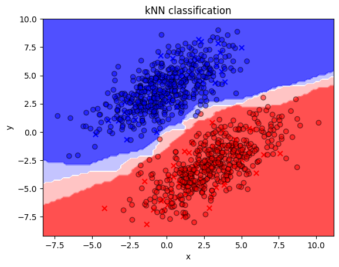

```python
import pandas as pd
import matplotlib.pyplot as plt
from sklearn.neighbors import KNeighborsClassifier
from sklearn.model_selection import train_test_split
from sklearn.inspection import DecisionBoundaryDisplay
from sklearn.metrics import confusion_matrix

data0 = pd.read_csv('/content/datasetA.csv', sep=',', header=None)
data1 = pd.read_csv('/content/datasetB.csv', sep=',', header=None)
X = pd.concat([data0, data1])
label = len(data0)*[0] + len(data1)*[1]

X_train, X_test, y_train, y_test = \
  train_test_split(X, label,
  train_size=0.1, random_state=4)

clf = KNeighborsClassifier(n_neighbors = 3)

clf.fit(X_train, y_train)

fig, ax = plt.subplots(1,1)
cm = 'bwr_r'

DecisionBoundaryDisplay.from_estimator(
  clf, X, cmap=cm, alpha=0.8, ax=ax)
predi = clf.predict(X_test)
score = clf.score(X_test, y_test)
print('Confusion matrix = ')
print(confusion_matrix(predi, y_test))
print(f'Accuracy = {score:.3}')

for i,(c1,c2) in enumerate(zip(y_test,predi)):
  if c1 != c2:
    x = X_test.iloc[i, 0]
    y = X_test.iloc[i, 1]
    print(f'({x},{y}) is classified as '
      f'{c2} but should be {c1}')
ax.scatter(X_train.iloc[:,0],X_train.iloc[:,1],
  c=y_train, cmap=cm, marker ='x')
ax.scatter(X_test.iloc[:,0], X_test.iloc[:,1],
  c=predi, cmap=cm, edgecolors="k",
  alpha=0.5,)
ax.set_title(r'kNN classification')
ax.set_xlabel('x')
ax.set_ylabel('y')

plt.show()
```

## Exercise:

8.11 all

every subproblem (only abc...) worth one point